# caret demostration with kaggle bikeshare data (I)

#### Model2: Try *caret::rpart* with 6-fold CV optimization

- try another tree-like model: CART using *caret::rpart*

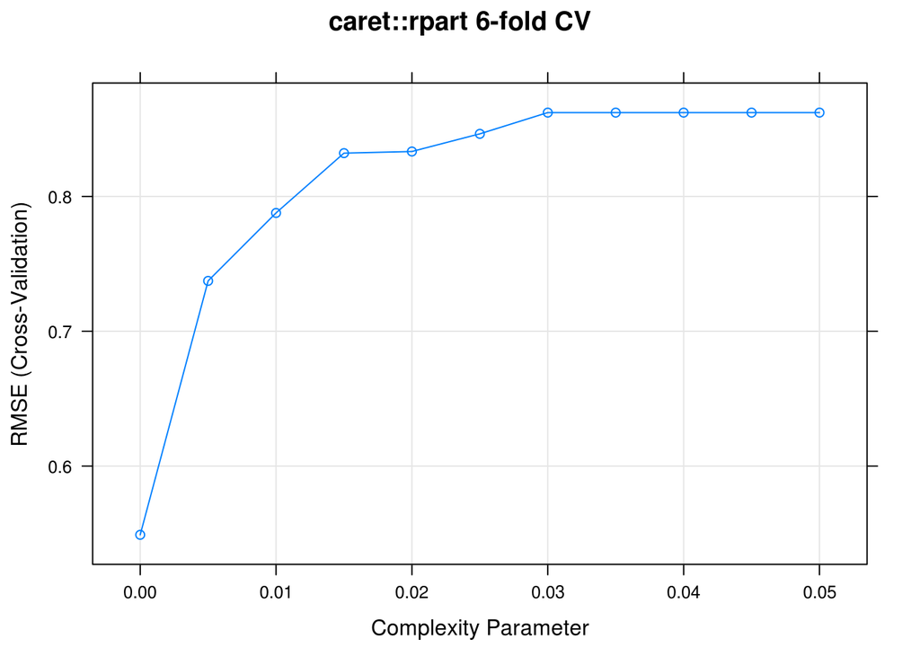

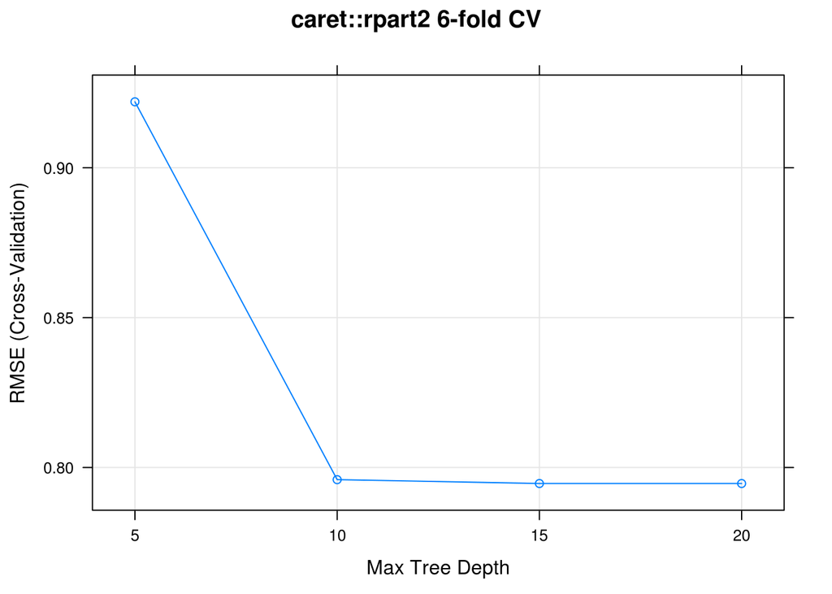

```
##           Test.rmsle Test.rmse Train.RMSLE Train.RMSE
## rpart.CV   0.5325579  79.97178   0.4049704   61.81217
## rpart2.CV  0.7847154 148.60228   0.7871033  145.48955
```

```
## [1] rpart.CV size:  6.6 Mb
```

```
## [1] rpart2.CV size:  6.2 Mb
```

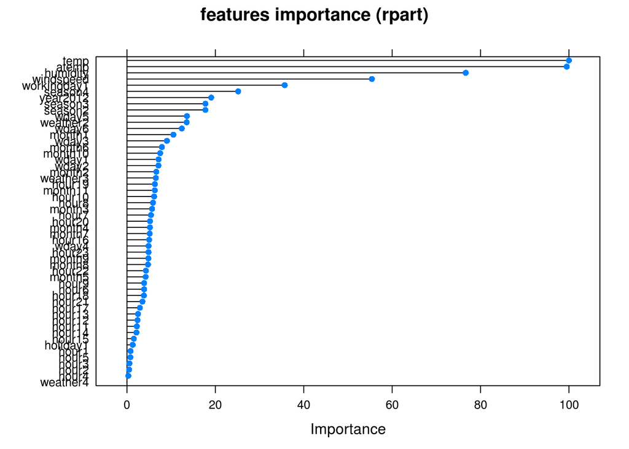

```r
##model2a: CART using rpart with CV
set.seed(123)
fitControl <- trainControl(method = 'cv', number=6)
Grid <- expand.grid(cp=seq(0, 0.05, 0.005))
formula <- lgcount ~ season + holiday + workingday + weather + temp + atemp + humidity + windspeed + hour + wday + month + year
fit.rpartCV <- train(formula, data=subTrain, method = 'rpart', trControl=fitControl, metric='RMSE',maximize=FALSE, tuneGrid = Grid)
##model2b: rpart2 with CV
set.seed(123)
formula <- lgcount ~ season + holiday + workingday + weather + temp + atemp + humidity + windspeed + hour + wday + month + year
fitControl <- trainControl(method = 'cv', number=6)
Grid<-expand.grid(.maxdepth=seq(5,20,5))
fit.rpart2CV <- train(formula, data=subTrain, method = 'rpart2', trControl=fitControl, metric = 'RMSE', maximize=FALSE, tuneGrid=Grid)
plot(fit.rpartCV)
plot(fit.rpart2CV)
```

- Ok. The performance is not better than *caret::ctree*. Especially, *rpart2* seems to stop improving at **maxdepth=10**. The rmsle is fixed to around 0.78 for the training set, which is almost the same for the testing set. The *rpart* model, on the other hand, converges to non-contrained model with **cp=0**. The RMSLE of the Training subsample is much smaller than the Testing subsample, which means overfitting.
- The models will treat the factorized features with more than two levels as multiple variables. The feature importance plot looks much more complex.
- However, the physical size of the models are much smaller than those from *ctree*.

### Esemble model: boosting / bagging / random forest

#### Model 3a: stocasting gradient boosting (*gbm*, 6-fold CV)

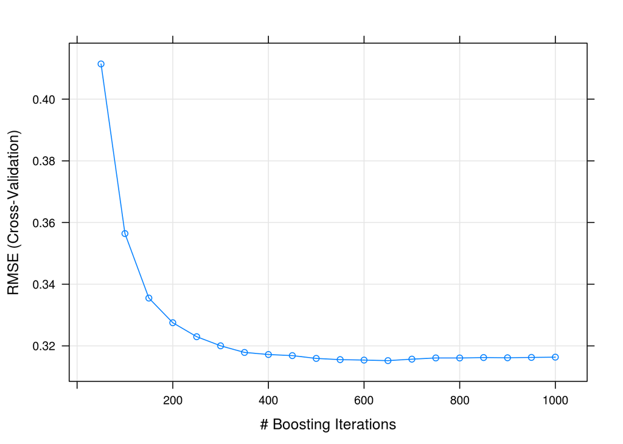

```
##        Test.rmsle Test.rmse Train.RMSLE Train.RMSE
## gbm.CV  0.3145828  43.72667   0.1658346   29.22251
```

```
## [1] object.size:  11.8 Mb
```

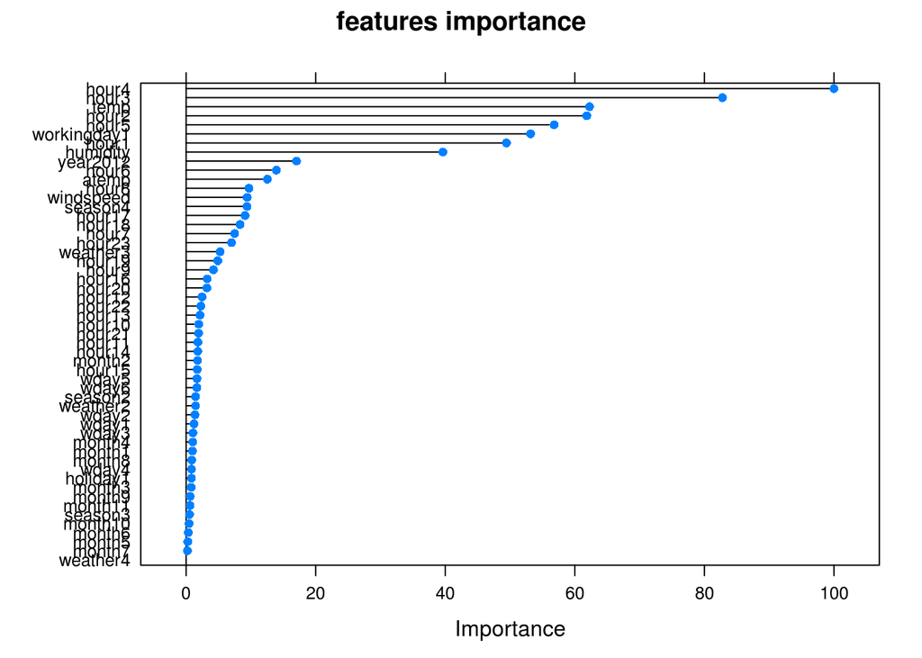

```r
## gbm fitting
set.seed(123)
fitControl <- trainControl(method = 'cv', number = 6, summaryFunction=defaultSummary)
Grid <- expand.grid( n.trees = seq(50,1000,50), interaction.depth = c(30), shrinkage = c(0.1))
formula <- lgcount ~ season + holiday + workingday + weather + temp + atemp + humidity + windspeed + hour + wday + month + year
fit.gbm <- train(formula, data=subTrain, method = 'gbm', trControl=fitControl,tuneGrid=Grid,metric='RMSE',maximize=FALSE)
plot(fit.gbm)
plot(gbmVarImp)
```

- The result seems to be very good.
- The model is optimized at n.tree$=650$ for shrinkage=0.1 and interaction=30. I will explore more on the parameter space later. Smaller shrinkage may reduce the risk of overfitting.
- The feature of hour is even more distinguished with this model. Also, *gbm*, like *rpart*, will treat multi-level features are multiple variables. I need to consider whether this is good or not. In this way, features like **hour** may be splitted into too many parameters which increase the complexity of models. On the other hand, we know the response of **hour** won’t be linear, which means we may not gain to use a single **hour** feature for naive linear regression.

#### Model 3b: Another boosting model - *gamboost* in *caret*

The model is from *mboost*. It is another realization of gradient bossting model with parameter **mstop**, the number of initial boosting iterations, and **prune**, which is not found in the original *mboost* guide.

```r
## gamboost fitting
set.seed(123)
fitControl <- trainControl(method = 'cv', number=6, summaryFunction=defaultSummary)
Grid <- expand.grid(.mstop=seq(100,1000,100),.prune=c(5))
formula <- lgcount ~ season + holiday + workingday + weather + temp + atemp + humidity + windspeed + hour + wday + month + year
fit.gamboost <- train(formula, data=subTrain, method = 'gamboost', trControl=fitControl,tuneGrid=Grid,metric='RMSE',maximize=FALSE)
```

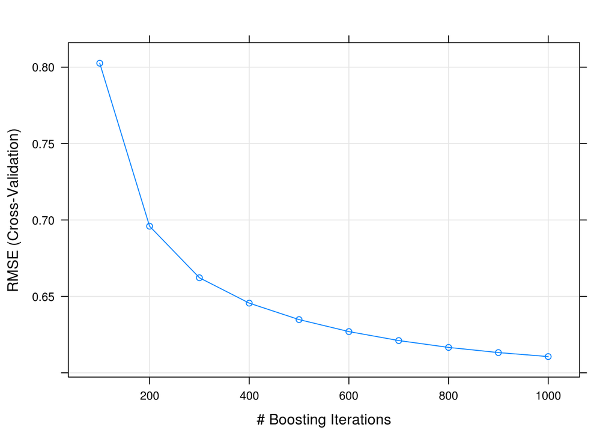

```
##             Test.rmsle Test.rmse Train.RMSLE Train.RMSE
## gamboost.CV  0.6140908  98.05113   0.6068851   96.41029
```

```
## [1] object.size:  10.9 Mb
```

- The RMSLE is worse than the model of *caret::gbm*. But, there shows no sign of overfitting.
- I suppose there should be some way to allow **prune** to vary, or there should be a parameter similar to **shrinkage** in *gbm*. Well, I don’t want to spend too much time on this, and move on to the next model.

#### Model 4a: bagged CART - *treebag* in *caret*

- The model is from *ipred*. In *caret*, it is simple, and no grid parameter to tune.

```r
## treebag fitting
set.seed(123)
fitControl <- trainControl(method = 'none', summaryFunction=defaultSummary)
formula <- lgcount ~ season + holiday + workingday + weather + temp + atemp + humidity + windspeed + hour + wday + month + year
fit.treebag <- train(formula, data=subTrain, method = 'treebag', trControl=fitControl)
show(fit.treebag)
save(fit.treebag,file='fit_treebag_v1.RData')
```

```
##            Test.rmsle Test.rmse Train.RMSLE Train.RMSE
## treebag.CV  0.7499689  147.1881   0.7484233   143.1211
```

```
## [1] object.size:  132.5 Mb
```

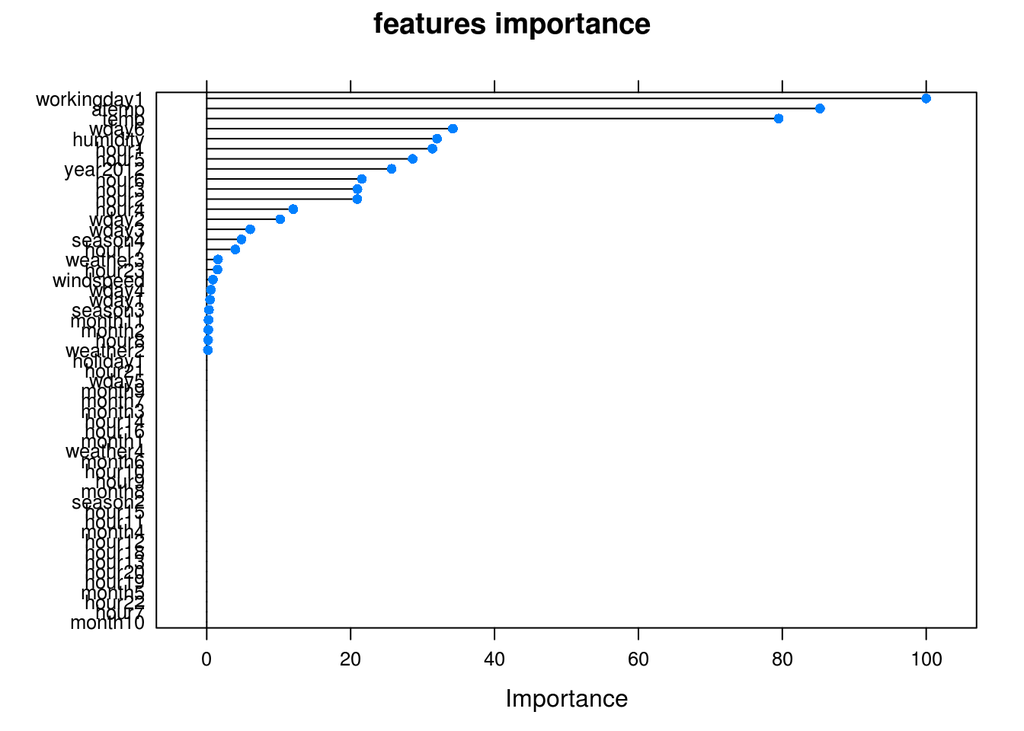

- Ok. Not surprisingly, the performance is worse than the boosted models.
- I suppose this is based on *rpart* models, so that the multi-level features will be splitted. In addition, the result is not storage-friendly, and the calculation is quite slow.

#### Model 4b: bagged MARS - bagEarth in caret/earth

According to the *caret* guide, *bagEarth* is ‘A bagging wrapper for multivariate adaptive regression splines (MARS) via the earth function’.

```r
## bagEarth fitting
set.seed(123)
fitControl <- trainControl(method = 'cv', number = 6, summaryFunction=defaultSummary)
Grid <- expand.grid(degree=c(2), nprune = seq(10,90,20))
formula <- lgcount ~ season + holiday + workingday + weather + temp + atemp + humidity + windspeed + hour + wday + month + year
fit.bagEarth <- train(formula, data=subTrain, method = 'bagEarth', trControl=fitControl,tuneGrid=Grid,metric='RMSE',maximize=FALSE,keepX=FALSE)
#show(fit.bagEarth)
```

- There is also similar problem with *caret::treebag*, the tunning parameters aren’t under my control. **degree** seems to be held at the first value I feed in.
- Another problem is the result is unnecessarily large (>300MBs), and very time consuming to run. It is even slower than random forest.

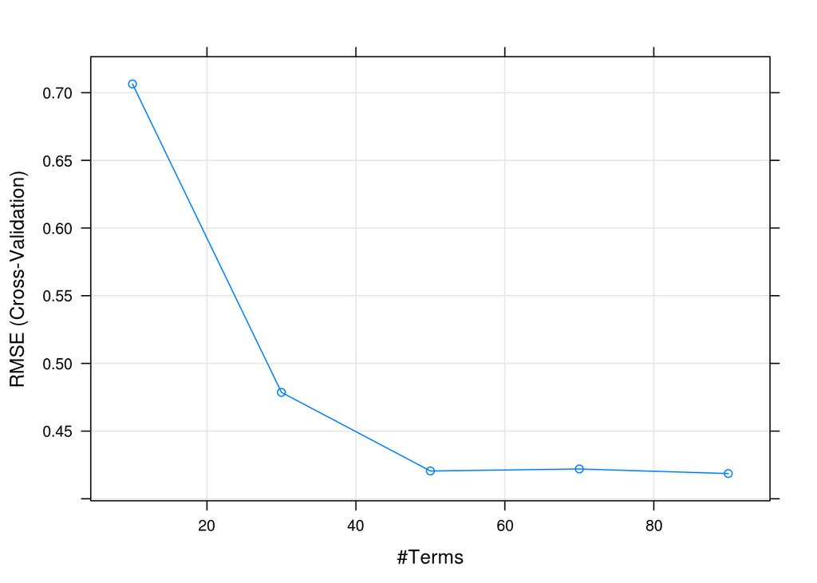

```
##             Test.rmsle Test.rmse Train.RMSLE Train.RMSE
## bagEarth.CV  0.4242703  69.00662   0.4115398    68.0136
```

```
## [1] object.size:  383.9 Mb
```

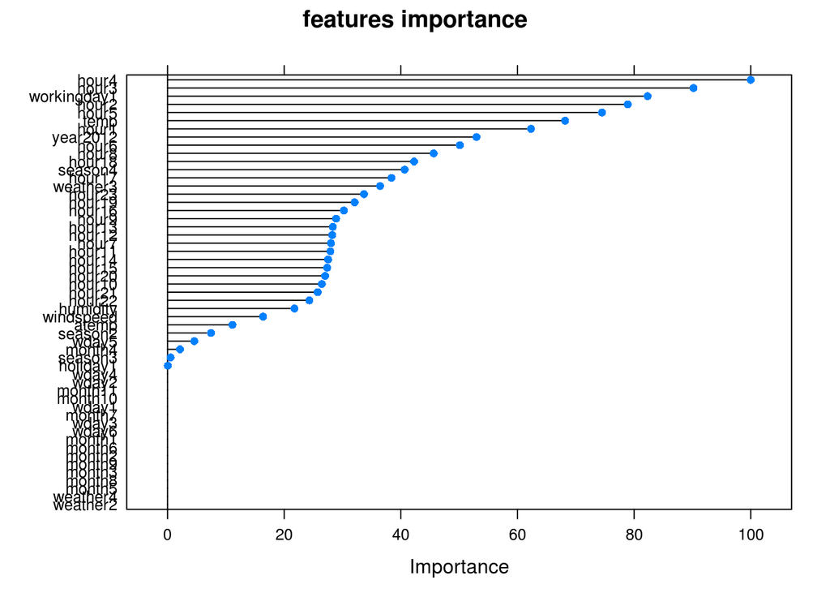

- The RMSLE is ok ~ 0.42 for Testing subsample with degree$=2$. It seems to be not overfitting.

#### Model 5: random forest (*rf*, oob)

```r
# random forest
set.seed(123)
tc <- trainControl("oob")
Grid <- expand.grid(mtry = seq(4,16,4))
formula <- lgcount ~ season + holiday + workingday + weather + temp + atemp + humidity + windspeed + hour + wday + month + year
fit.rf <- train(formula, data=subTrain , method='rf', trControl=tc,tuneGrid=Grid,metric='RMSE')
```

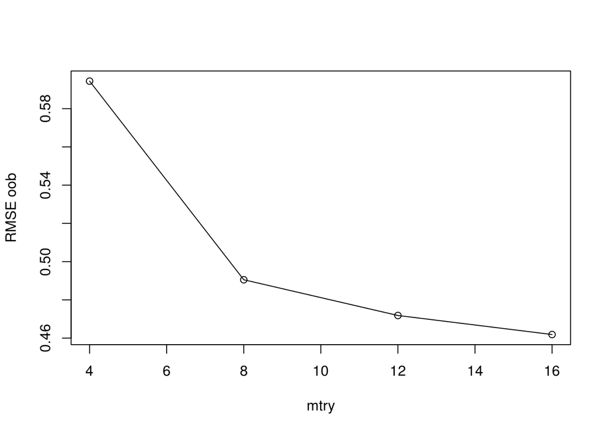

```
##        RMSE  Rsquared mtry
## 1 0.5943940 0.8238771    4
## 2 0.4905211 0.8800549    8
## 3 0.4718308 0.8890213   12
## 4 0.4618798 0.8936531   16
```

```
##        Test.rmsle Test.rmse Train.RMSLE Train.RMSE
## rf.oob  0.4718695  74.40514   0.2334819   38.81704
```

```
## [1] object.size:  91.9 Mb
```

#### Model 5b: try random forest with 4-fold CV

```r
# random forest
set.seed(123)
tc <- trainControl("cv",number=4)
Grid <- expand.grid(mtry = seq(4,16,4))
formula <- lgcount ~ season + holiday + workingday + weather + temp + atemp + humidity + windspeed + hour + wday + month + year
fit.rf.cv <- train(formula, data=subTrain , method='rf', trControl=tc,tuneGrid=Grid,metric='RMSE')
```

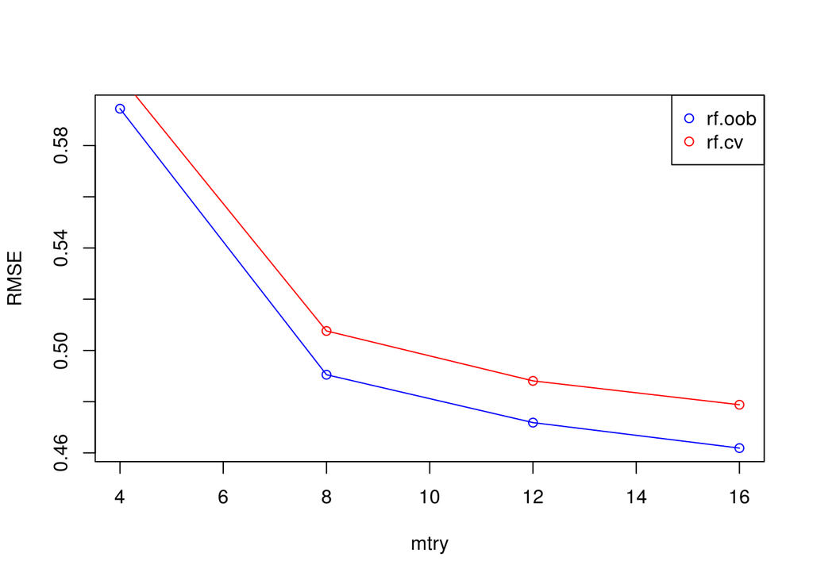

```
##   mtry      RMSE  Rsquared      RMSESD  RsquaredSD
## 1    4 0.6070140 0.8597777 0.012837362 0.005337229
## 2    8 0.5076205 0.8808282 0.010867871 0.005845244
## 3   12 0.4881242 0.8852147 0.008540236 0.006206083
## 4   16 0.4788093 0.8878842 0.009833839 0.006777247
```

```
##        Test.rmsle Test.rmse Train.RMSLE Train.RMSE
## rf.cv   0.4685932  73.94653   0.2325217   38.51168
## rf.oob  0.4718695  74.40514   0.2334819   38.81704
```

- All right. No surprise. They are similar.

### A quick table of all model performances

```r
  show(compare)
```

[output not shown]

### Submission of the Prediction

- Let’s try submiting the predictions of gbm.cv, rf.cv, ctree.party, bagEarth.cv.

```r
#run model against test data set
predict.rf <- predict(fit.rf.cv, test_factor)
predict.rf <- exp(predict.rf) - 1
#build a dataframe with our results
submit.rf <- data.frame(datetime = test$datetime, count=predict.rf)
#write results to .csv for submission
write.csv(submit.rf, file="submit_rf_v1.csv",row.names=FALSE,quote=FALSE)

#run model against test data set
predict.gbm <- predict(fit.gbm, test_factor)
predict.gbm <- exp(predict.gbm) - 1
#build a dataframe with our results
submit.gbm <- data.frame(datetime = test$datetime, count=predict.gbm)
#write results to .csv for submission
write.csv(submit.gbm, file="submit_gbm_v1.csv",row.names=FALSE,quote=FALSE)

#bagEarth
#run model against test data set
predict.bagEarth <- predict(fit.bagEarth, test_factor)
predict.bagEarth <- exp(predict.bagEarth) - 1
#build a dataframe with our results
submit.bagEarth <- data.frame(datetime = test$datetime, count=predict.bagEarth)
#write results to .csv for submission
write.csv(submit.bagEarth, file="submit_bagEarth_v1.csv",row.names=FALSE,quote=FALSE)

#ctree.party
#run model against test data set
predict.ctree <- predict(fit.ctree.party, test_factor)
colnames(predict.ctree) = 'count'
predict.ctree <- exp(predict.ctree) - 1
#build a dataframe with our results
submit.ctree <- data.frame(datetime = test$datetime, count=predict.ctree)
#write results to .csv for submission
write.csv(submit.ctree, file="submit_ctree_v1.csv",row.names=FALSE,quote=FALSE)
```

| Models | scores | Test.rmsle |
| --- | --- | --- |
| rf.cv | 0.517 | 0.469 |
| gbm.cv | 0.402 | 0.315 |
| bagEarth.cv | 0.451 | 0.424 |
| ctree.party | 0.524 | 0.417 |

### Summary

1. *caret* provides a nice integrated user interface of the large model set. I won’t be able to try so many different models in these few days without *caret*. However, we may need to go back to the original package for further tunning, unless if there are some mysterious tricks I don’t know.
2. Some models are tremendously storage-consuming, which may cause slow calculation.
3. I need to consider more carefully, whether the parameters (especially multi-leveled parameters like hours) should be leveled or not.
4. My random forest model must be overfitted. I will fix it in the next run.

### To Be Continued …

- I will use more random forest, linear regression, and radial-kernal regression in the next file: bikeshare-demand.2.Rmd.